# A Crash Course in Digital Accessibility

[@tonyfast](https://github.com/tonyfast) s notebooks

**title**

A Crash Course in Digital Accessibility

**description**

this document is full of links for you to visit later, and learn at your own pace. this is a 5 minute link dump about my special interest. with a surprise demo!

**state**

executed in order

**kernel**

**language**

python

**name**

**lines of code**

**outputs**

7

accessible notebook interfaces

compliance ≠ assistive

manually reviewing accessibility

other useful sources sources

conclusion

whats the deal with the demo??

cell_type

toolbar

source

loc

In [ ]

markdown

actions

```
# A Crash Course in Digital Accessibility

this document is full of links for you to visit later, and learn at your own pace.
this is a 5 minute link dump about my special interest.
with a surprise demo!

* w3c accessibility standards
* accessibility auditing tools and practices
* language used in the accessibility circles
* how disability impacts us all.

<figure markdown>

![image.png](attachment:4d2af2cf-f339-4de6-9f04-a447f96fb5e6.png "qrcode to tonyfast.github.io")

<figcaption markdown>

## history

* [original content developed for pycascades 2023 lightning talks](https://tonyfast.github.io/tonyfast/xxiii/2023-03-18-pycascades-ally-talk.htmlhttps://tonyfast.github.io/tonyfast/xxiii/2023-03-18-pycascades-ally-talk.html)
* [updated for bellingham codes on 7/6](https://www.meetup.com/bellinghamcodes/events/294458693/)

</figcaption>
</figure>


<form id="controls">
    <label for="run">🏃</label><button id="run" data-commandlinker-command="notebook:run-all-cells">run all</button>
    <label for="doc">🖹</label><button id="doc" data-commandlinker-command="application:toggle-mode">document mode</button>
    <label for="prez">📽</label><button id="prez" data-commandlinker-command="application:toggle-presentation-mode">presentation mode</button>
    <label for="collapse">⊟</label><button id="collapse" data-commandlinker-command="notebook:hide-all-cell-code">collapse all the code</button>
    <br/>
    <label for="expand">⊞</label><button id="expand" data-commandlinker-command="notebook:show-all-cell-code">expand all the code</button>
    <button data-commandlinker-command="deck:toggle"><code>jupyterlab-deck</code></button>
    <button data-commandlinker-command="notebook:render-with-voila"><code>voila</code></button>
    <label for="inspectoropen">🔍</label><button id="inspectoropen" data-commandlinker-command="inspector:open">inspector</button>
    <label title="open side by side view" for="right">👯</label><button id="right" data-commandlinker-command="notebook:toggle-render-side-by-side-current">side-by-side</button>
</form>
```

38

# A Crash Course in Digital Accessibility

this document is full of links for you to visit later, and learn at your own pace. this is a 5 minute link dump about my special interest. with a surprise demo!

- w3c accessibility standards
- accessibility auditing tools and practices
- language used in the accessibility circles
- how disability impacts us all.

[figure not shown]

## history

- [original content developed for pycascades 2023 lightning talks](https://tonyfast.github.io/tonyfast/xxiii/2023-03-18-pycascades-ally-talk.htmlhttps://tonyfast.github.io/tonyfast/xxiii/2023-03-18-pycascades-ally-talk.html)
- [updated for bellingham codes on 7/6](https://www.meetup.com/bellinghamcodes/events/294458693/)

In [ 1 ]

code

actions

```
    %reload_ext pidgy
```

2

In [ 2 ]

code

actions

```
## WHO global disability stats

<blockquote markdown cite="https://www.who.int/news-room/fact-sheets/detail/disability-and-health">

* An estimated 1.3 billion people experience significant disability. This represents 16% of the world’s population, or 1 in 6 of us.
* Some persons with disabilities die up to 20 years earlier than those without disabilities.
* Persons with disabilities have twice the risk of developing conditions such as depression, asthma, diabetes, stroke, obesity or poor oral health.
* Persons with disabilities face many health inequities.
* Persons with disabilities find inaccessible and unaffordable transportation 15 times more difficult than for those without disabilities.
* Health inequities arise from unfair conditions faced by persons with disabilities, including stigma, discrimination, poverty, exclusion from education and employment, and barriers faced in the health system itself.

</blockquote>
```

12

## WHO global disability stats

> - An estimated 1.3 billion people experience significant disability. This represents 16% of the world’s population, or 1 in 6 of us.
> - Some persons with disabilities die up to 20 years earlier than those without disabilities.
> - Persons with disabilities have twice the risk of developing conditions such as depression, asthma, diabetes, stroke, obesity or poor oral health.
> - Persons with disabilities face many health inequities.
> - Persons with disabilities find inaccessible and unaffordable transportation 15 times more difficult than for those without disabilities.
> - Health inequities arise from unfair conditions faced by persons with disabilities, including stigma, discrimination, poverty, exclusion from education and employment, and barriers faced in the health system itself.

In [ ]

markdown

actions

```
## forms of disability



![](https://trailheadtechnology.com/wp-content/uploads/2021/02/BlogImage1.png "an illustration about the physical axes of disability (ie touch see hear speak) and the temporal axes(ie permanent temporary sitational)an illustration about the physical axes of disability (ie touch see hear speak) and the temporal axes(ie permanent temporary sitational)")

from [microsoft inclusive design](https://inclusive.microsoft.design/)
```

7

## forms of disability

[figure not shown]

from [microsoft inclusive design](https://inclusive.microsoft.design/)

In [ 3 ]

code

actions

[output not shown]

41

In [ 4 ]

code

actions

```
### practical wuh-cag guidelines

<figure markdown>
<figcaption markdown>

summarized guidelines on the [wcag wikipedia](https://en.wikipedia.org/wiki/Web_Content_Accessibility_Guidelines)

</figcaption>
<blockquote markdown cite="https://en.wikipedia.org/wiki/Web_Content_Accessibility_Guidelines">

* Guideline 1: Provide equivalent alternatives to auditory and visual content
* Guideline 2: Don't rely on colour alone
* Guideline 3: Use markup and style sheets, and do so properly
* Guideline 4: Clarify natural language usage
* Guideline 5: Create tables that transform gracefully
* Guideline 6: Ensure that pages featuring new technologies transform gracefully
* Guideline 7: Ensure user control of time sensitive content changes
* Guideline 8: Ensure direct accessibility of embedded user interfaces
* Guideline 9: Design for device independence
* Guideline 10: User interim solutions
* Guideline 11: Use W3C technologies and guidelines
* Guideline 12: Provide context and orientation information
* Guideline 13: Provide clear navigation mechanisms
* Guideline 14: Ensure that documents are clear and simple

</blockquote>
```

26

### practical wuh-cag guidelines

summarized guidelines on the [wcag wikipedia](https://en.wikipedia.org/wiki/Web_Content_Accessibility_Guidelines)

> - Guideline 1: Provide equivalent alternatives to auditory and visual content
> - Guideline 2: Don't rely on colour alone
> - Guideline 3: Use markup and style sheets, and do so properly
> - Guideline 4: Clarify natural language usage
> - Guideline 5: Create tables that transform gracefully
> - Guideline 6: Ensure that pages featuring new technologies transform gracefully
> - Guideline 7: Ensure user control of time sensitive content changes
> - Guideline 8: Ensure direct accessibility of embedded user interfaces
> - Guideline 9: Design for device independence
> - Guideline 10: User interim solutions
> - Guideline 11: Use W3C technologies and guidelines
> - Guideline 12: Provide context and orientation information
> - Guideline 13: Provide clear navigation mechanisms
> - Guideline 14: Ensure that documents are clear and simple

In [ 5 ]

code

actions

```
## alphabet soup of accessibility web standards

documentation! web apps! reports! anything in the browser! [video games!](https://gameaccessibilityguidelines.com/)

* <abbr title="web accessibility initiative">WAI</abbr> [web accessibility initiative](https://www.w3.org/WAI/)
* <abbr title="web content accessibility guidelines">WCAG</abbr> [web content accessibility guidelines](https://www.w3.org/WAI/standards-guidelines/)
* <abbr title="accessible rich internet applications">ARIA</abbr> [accessible rich internet applications](https://www.w3.org/WAI/standards-guidelines/aria/)

  > [no aria is better than bad aria.](https://www.w3.org/WAI/ARIA/apg/practices/read-me-first/)

* <abbr title="ARIA Authoring Practices Guide">APG</abbr> [aria authoring practices guide](https://www.w3.org/WAI/ARIA/apg/patterns/)
* <abbr title="accessibility conformance testing">ACT</abbr> [accessibility conformance testing](https://www.w3.org/WAI/standards-guidelines/act/rules/)
* <abbr title="accessibility object model">AOM</abbr> [accessibility object model](https://wicg.github.io/aom/spec/)
* <abbr title="Authoring Tool Accessibility Guidelines">ATAG</abbr> [authoring tool accessibility guidelines](https://www.w3.org/WAI/standards-guidelines/atag/)
* 🆕 [Cognitive Accessibility at W3C](https://www.w3.org/WAI/cognitive/)
```

16

## alphabet soup of accessibility web standards

documentation! web apps! reports! anything in the browser! [video games!](https://gameaccessibilityguidelines.com/)

- WAI [web accessibility initiative](https://www.w3.org/WAI/)
- WCAG [web content accessibility guidelines](https://www.w3.org/WAI/standards-guidelines/)
- ARIA [accessible rich internet applications](https://www.w3.org/WAI/standards-guidelines/aria/)

  > [no aria is better than bad aria.](https://www.w3.org/WAI/ARIA/apg/practices/read-me-first/)
- APG [aria authoring practices guide](https://www.w3.org/WAI/ARIA/apg/patterns/)
- ACT [accessibility conformance testing](https://www.w3.org/WAI/standards-guidelines/act/rules/)
- AOM [accessibility object model](https://wicg.github.io/aom/spec/)
- ATAG [authoring tool accessibility guidelines](https://www.w3.org/WAI/standards-guidelines/atag/)
- 🆕 [Cognitive Accessibility at W3C](https://www.w3.org/WAI/cognitive/)

In [ 6 ]

code

actions

```
## auditting accessibility

where applicable, build the accessibility floor by using these in ci.

* 👋 [Deque Labs Axe](https://github.com/dequelabs/axe-core)
* 👋 [IBM Equal Access](https://github.com/IBMa/equal-access/tree/master)
* 👋 [WAVE accessibility evaluator](https://wave.webaim.org/extension/)
* [W3C markup validator](https://validator.w3.org/)
```

8

## auditting accessibility

where applicable, build the accessibility floor by using these in ci.

- 👋 [Deque Labs Axe](https://github.com/dequelabs/axe-core)
- 👋 [IBM Equal Access](https://github.com/IBMa/equal-access/tree/master)
- 👋 [WAVE accessibility evaluator](https://wave.webaim.org/extension/)
- [W3C markup validator](https://validator.w3.org/)

In [ ]

markdown

actions

```
## accessible notebook interfaces
<figure markdown>
<figcaption markdown>

recently, Jupyter developers were able to remove accessibility violations caught be axe. read the [blog post].

</figcaption>

![image.png](attachment:da0e9339-76c6-4ddf-8695-4c804430a227.png "axe auditting results comparing the vioations before remediation and afterwards.")
</figure>

<h1 role=presentation>compliance ≠ assistive</h1>

[blog post]: https://blog.jupyter.org/improving-the-accessibility-of-jupyter-6c695db518d3
```

14

## accessible notebook interfaces

recently, Jupyter developers were able to remove accessibility violations caught be axe. read the [blog post](https://blog.jupyter.org/improving-the-accessibility-of-jupyter-6c695db518d3) .

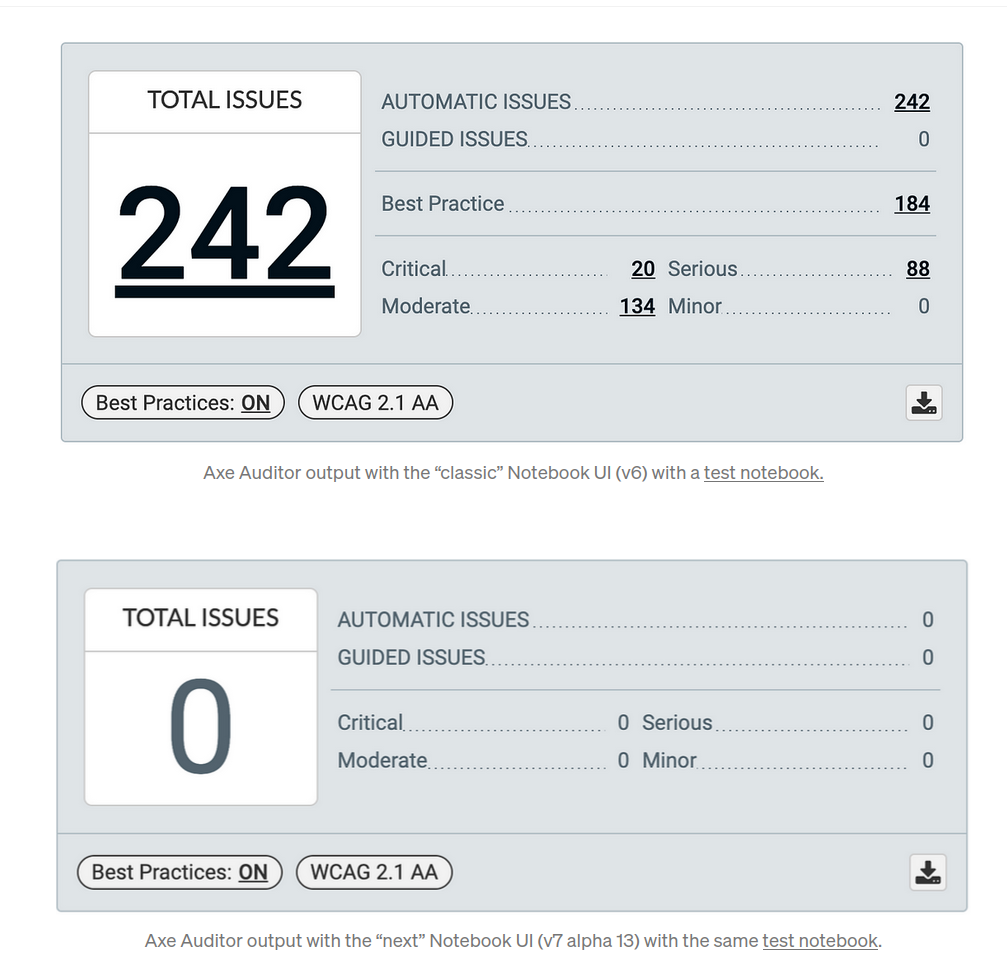

# compliance ≠ assistive

In [ ]

markdown

actions

```
<details markdown>
<summary>Notebooks for All</summary>
<blockquote cite="https://github.com/Iota-School/notebooks-for-all" markdown>

Jupyter Notebooks play a central role in modern data science workflows. Despite their importance, these notebooks are inaccessible to people with disabilities, especially those who rely on assistive technology. Impacted users must find extreme workarounds or [give up using them entirely.](https://www.freelists.org/post/program-l/Accessability-of-Jupyter-notebooks) Students with disabilities have [reported leaving their field](https://github.com/jupyterlab/jupyterlab/issues/9399#issuecomment-740524422) once they learn their chosen career’s foundational tools are inaccessible to them.

This is a challenging problem to solve. The Notebooks for All project is taking the first steps, initially focusing on static notebooks:
- Running usability feedback sessions with impacted users who rely on a variety of assistive technology
- Capturing what makes notebooks inaccessible with assistive technology, and compiling documents that describe the issues and feedback
- Editing notebooks based on the feedback
- Organizing events to spread awareness in the scientific community about this issue
-
</blockquote>

| when | example |
|---|-------|
|before|https://nbviewer.org/github/jupyter-widgets/ipywidgets/blob/main/docs/source/examples/Lorenz%20Differential%20Equations.ipynb|
|after|https://iota-school.github.io/notebooks-for-all/exports/html/lorenz-executed-smol.html|

> we designed notebooks based on their semantics to improve the quality of the annotation object model, and assistive tech experience.


</details>

[notebooks for all]: https://github.com/Iota-School/notebooks-for-all
```

25

**Notebooks for All**

Jupyter Notebooks play a central role in modern data science workflows. Despite their importance, these notebooks are inaccessible to people with disabilities, especially those who rely on assistive technology. Impacted users must find extreme workarounds or [give up using them entirely.](https://www.freelists.org/post/program-l/Accessability-of-Jupyter-notebooks) Students with disabilities have [reported leaving their field](https://github.com/jupyterlab/jupyterlab/issues/9399#issuecomment-740524422) once they learn their chosen career’s foundational tools are inaccessible to them.

This is a challenging problem to solve. The Notebooks for All project is taking the first steps, initially focusing on static notebooks:

- Running usability feedback sessions with impacted users who rely on a variety of assistive technology
- Capturing what makes notebooks inaccessible with assistive technology, and compiling documents that describe the issues and feedback
- Editing notebooks based on the feedback
- Organizing events to spread awareness in the scientific community about this issue

| when | example |
| --- | --- |
| before | https://nbviewer.org/github/jupyter-widgets/ipywidgets/blob/main/docs/source/examples/Lorenz%20Differential%20Equations.ipynb |
| after | https://iota-school.github.io/notebooks-for-all/exports/html/lorenz-executed-smol.html |

> we designed notebooks based on their semantics to improve the quality of the annotation object model, and assistive tech experience.

In [ ]

markdown

actions

2023-03-19T02:35:45.194647+00:00

2023-03-19T02:35:45.200620+00:00

```
## manually reviewing accessibility

there are a lot of dimensions to digital accessibility. here are some things i thought worth noting.

* [reviewing accessible design principles](https://adhoc.team/2023/02/22/the-importance-of-adding-accessibility-design-reviews-to-the-design-process/)
    * Consider focus order
       ![image.png](attachment:6fc33e67-287c-4346-80ba-18435302868f.png)

    * Examine copy
    * Pay attention to colors
    * Look at page context and components
    * Annotate the designs
* [The A11Y Project](https://www.a11yproject.com/) is an open source community about accessibility with tons of resources

  ![image.png](attachment:07102a1b-9748-4ac5-ba32-a62a2638bbd0.png)

  * [no mouse days](https://www.a11yproject.com/posts/no-mouse-days/)
* [technica11y](https://www.technica11y.org/) produces first hand accounts of disabled develops
* [community events](https://github.com/isabela-pf/a11y-events/tree/main/workshop-resources/alt-text)
    * [collaborative alt text documentation events](https://github.com/isabela-pf/a11y-events/tree/main/workshop-resources/alt-text)

      ![image.png](attachment:faf3db7e-98a6-4cfd-85b1-9b16afef905b.png)

    * [keyboard navigation events](https://github.com/isabela-pf/a11y-events/tree/main/workshop-resources/keyboard-navigation)

* [meet your screen reader](https://en.wikipedia.org/wiki/List_of_screen_readers)
```

26

## manually reviewing accessibility

there are a lot of dimensions to digital accessibility. here are some things i thought worth noting.

- [reviewing accessible design principles](https://adhoc.team/2023/02/22/the-importance-of-adding-accessibility-design-reviews-to-the-design-process/)
  - Consider focus order

[figure not shown]

  - Examine copy
  - Pay attention to colors
  - Look at page context and components
  - Annotate the designs
- [The A11Y Project](https://www.a11yproject.com/) is an open source community about accessibility with tons of resources

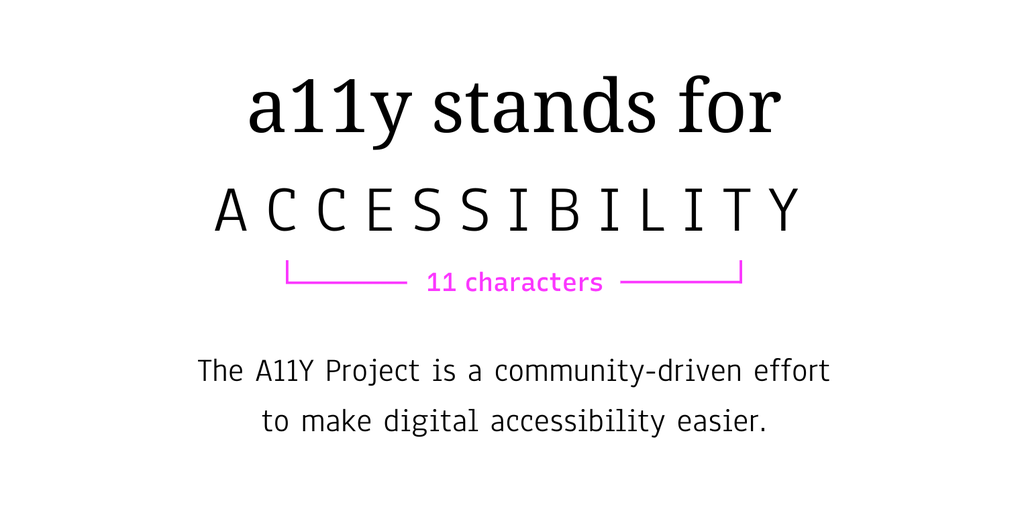

  - [no mouse days](https://www.a11yproject.com/posts/no-mouse-days/)
- [technica11y](https://www.technica11y.org/) produces first hand accounts of disabled develops
- [community events](https://github.com/isabela-pf/a11y-events/tree/main/workshop-resources/alt-text)
  - [collaborative alt text documentation events](https://github.com/isabela-pf/a11y-events/tree/main/workshop-resources/alt-text)

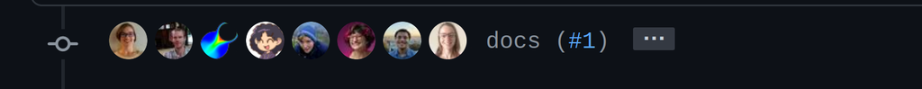

  - [keyboard navigation events](https://github.com/isabela-pf/a11y-events/tree/main/workshop-resources/keyboard-navigation)
- [meet your screen reader](https://en.wikipedia.org/wiki/List_of_screen_readers)

In [ ]

markdown

actions

```
## other useful sources sources

* [chartability](https://chartability.fizz.studio/https://chartability.fizz.studio/)
* [wai patterns](https://www.w3.org/WAI/ARIA/apg/patterns/https://www.w3.org/WAI/ARIA/apg/patterns/)
* [diagram center general guidelines](http://diagramcenter.org/general-guidelines-final-draft.html)
* Frameworks? [Modern Health, frameworks, performance, and harm Modern Health, frameworks, performance, and harm ](https://ericwbailey.website/published/modern-health-frameworks-performance-and-harm/)
* [Do No Harm Guide: Applying Equity Awareness in Data Visualization](https://www.urban.org/research/publication/do-no-harm-guide-applying-equity-awareness-data-visualization)
* [accessible pygments themes for code](https://github.com/Quansight-Labs/accessible-pygmentshttps://github.com/Quansight-Labs/accessible-pygments)
```

8

## other useful sources sources

- [chartability](https://chartability.fizz.studio/https://chartability.fizz.studio/)
- [wai patterns](https://www.w3.org/WAI/ARIA/apg/patterns/https://www.w3.org/WAI/ARIA/apg/patterns/)
- [diagram center general guidelines](http://diagramcenter.org/general-guidelines-final-draft.html)
- Frameworks? [Modern Health, frameworks, performance, and harm Modern Health, frameworks, performance, and harm](https://ericwbailey.website/published/modern-health-frameworks-performance-and-harm/)
- [Do No Harm Guide: Applying Equity Awareness in Data Visualization](https://www.urban.org/research/publication/do-no-harm-guide-applying-equity-awareness-data-visualization)
- [accessible pygments themes for code](https://github.com/Quansight-Labs/accessible-pygmentshttps://github.com/Quansight-Labs/accessible-pygments)

In [ 7 ]

code

actions

```
## conclusion

* diversity of thought and experience
* [inclusive design](https://en.wikipedia.org/wiki/Inclusive_design) practices and accessible principles are beacons for design
* include (and pay) disabled people - [nothing about us without us](https://en.wikipedia.org/wiki/Nothing_about_us_without_us)
    * [Why Underemployment Plagues People With Disabilities Even In A Strong Economy](https://www.forbes.com/sites/denisebrodey/2019/10/26/why-underemployment-plagues-people-with-disabilities-even-in-a-strong-economy/?sh=44006eeb693d)
```

6

## conclusion

- diversity of thought and experience
- [inclusive design](https://en.wikipedia.org/wiki/Inclusive_design) practices and accessible principles are beacons for design
- include (and pay) disabled people - [nothing about us without us](https://en.wikipedia.org/wiki/Nothing_about_us_without_us)
  - [Why Underemployment Plagues People With Disabilities Even In A Strong Economy](https://www.forbes.com/sites/denisebrodey/2019/10/26/why-underemployment-plagues-people-with-disabilities-even-in-a-strong-economy/?sh=44006eeb693d)

In [ ]

markdown

actions

2023-03-19T02:45:11.413446+00:00

2023-03-19T02:45:11.417473+00:00

```
## whats the deal with the demo??

* running the browser with jupyterlite

 [![image.png](attachment:edfd159c-9d27-4253-83ea-e754baf704b8.png "jupyterlite is jupyter in the browser")][jupyterlite]

* programmined in markdown with [pidgy]

  [![](https://github.com/deathbeds/pidgy/raw/main/pidgy.png "pidgy is literate programming in markdown and notebooks")][pidgy]

* presented with [jupyterlab-deck]

  [![image.png](attachment:db7ba277-b72a-488b-897c-9f3f8b26437d.png "jupyter deck is a lightweight presentation for jupyterlab")][jupyterlab-deck]

[jupyterlite]: https://jupyterlite.readthedocs.io/
[jupyterlab-deck]: https://github.com/deathbeds/jupyterlab-deck
[pidgy]: https://github.com/deathbeds/pidgyhttps://github.com/deathbeds/pidgy
```

17

## whats the deal with the demo??

- running the browser with jupyterlite

[figure not shown]

- programmined in markdown with pidgy

[figure not shown]

- presented with jupyterlab-deck

[figure not shown]